# Trabalho_2_IA

## Trabalho 2

**Projeto de Aprendizado de Máquina**

| Nome | #USP |
| --- | --- |
| Ciro Grossi Falsarella | 11795593 |
| Gabriel Tavares Brayn Rosati | 11355831 |
| Laura Nannetti Moreira | 12557504 |
| Mariana Faria Ribeiro de Souza | 10352200 |

### Imports

```python
# Data manipulation usage
import numpy as np
import pandas as pd


# Plotting
import seaborn as sns
from seaborn import heatmap
from seaborn import clustermap
from seaborn import boxplot
from seaborn import pairplot

import matplotlib.pyplot as plt


# Classification and modeling
from sklearn.neighbors import KNeighborsClassifier
from sklearn.tree import DecisionTreeClassifier
from sklearn.naive_bayes import MultinomialNB
from sklearn.neural_network import MLPClassifier

from sklearn.model_selection import cross_val_score
from sklearn.preprocessing import LabelEncoder
```

```python
# Data sets that will be used in the notebook
# Has a big ammount of outputs
%%capture

!gdown --id 1_oNiekjVG1D4je1vHPPkh8Qr9mQL-16a ## Leaf
!gdown --id 1yLZr9RMOp4WV3Fk-H3Kj6r0T4B8oPBEu ## Iris
!gdown --id 1Bf-IrqZjlS5aqd23oMWbicx33Ly6_0lF ## Mamographic Mass
!gdown --id 1-gKO8a51c7S7L_W1CiW_GA3poAqEO-9v ## Breast Cancer
```

### Usefull Functions

```python
# Absolute difference between 2 means, considering error
# Used to
def abs_dif(a,a_std,b,b_std):
    return (a-b)/np.sqrt((a_std**2 + b_std**2)/2)
```

## DataSets

### **Iris**

This dataset contains information about iris (flower), contemplating it's size. For the first test we choose an easier and basic data set, without any missing values or atributes that need to be reconfigurated.

#### **Data Frame**

```python
# Header defined to the dataset as specified in UCI site
iris_header =[
    "sepal length",
    "sepal width",
    "petal length",
    "petal width",
    "class"
]

df_iris = pd.read_csv("iris.data", header=None, names=iris_header)
```

```python
# We can see that the only non-numerical atribute is the class
# So, no treatment is needed
df_iris.info()
```

```
<class 'pandas.core.frame.DataFrame'>
RangeIndex: 150 entries, 0 to 149
Data columns (total 5 columns):
 #   Column        Non-Null Count  Dtype
---  ------        --------------  -----
 0   sepal length  150 non-null    float64
 1   sepal width   150 non-null    float64
 2   petal length  150 non-null    float64
 3   petal width   150 non-null    float64
 4   class         150 non-null    object
dtypes: float64(4), object(1)
memory usage: 6.0+ KB
```

Pairplot, to analise the clusters.

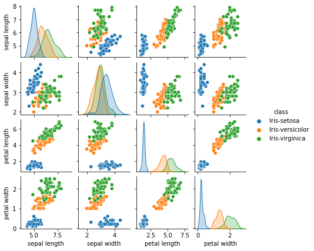

```python
# Pairplot using cluster in class atribute
pairplot(df_iris, hue="class", height=1.5)
```

A portion of the dataframe.

```python
df_iris.head()
```

|  | sepal length | sepal width | petal length | petal width | class |
| --- | --- | --- | --- | --- | --- |
| 0 | 5.1 | 3.5 | 1.4 | 0.2 | Iris-setosa |
| 1 | 4.9 | 3.0 | 1.4 | 0.2 | Iris-setosa |
| 2 | 4.7 | 3.2 | 1.3 | 0.2 | Iris-setosa |
| 3 | 4.6 | 3.1 | 1.5 | 0.2 | Iris-setosa |
| 4 | 5.0 | 3.6 | 1.4 | 0.2 | Iris-setosa |

#### **Pre-processing**

##### Missing Data

```python
# Count ammount of invalid data
# For the database, Invalid is represented by '?'
invalid = 0
for col in df_iris.columns:
  invalid += df_iris[df_iris[col] == '?'].shape[0]
print(f"{100*(1- invalid/df_iris.shape[0]):.2f}% of non-invalid rows")
```

```
100.00% of non-invalid rows
```

As there isn't invalid rows no treatment is needed

##### **Atribute Selection**

For reassurance, this test was made, using the correlation between the variables to select. As expected, every atribute will be used.

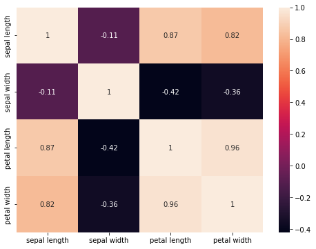

```python
# plotting a heatmap
# used to verify correlation with help of color display
f, ax = plt.subplots(figsize=(8, 6))
heatmap(df_iris.corr(), annot=True)
```

#### **Result**

##### **10-fold Cross Validation**

```python
## Use this operator to reduce the prints to what is wanted
%%capture --no-stdout

# Separate the data frame in data and target columns
data, target = df_iris.drop(columns=["class"]), df_iris["class"]

# Classify the values and print result + error
KNNaccuracy = cross_val_score(KNeighborsClassifier(), data, target, cv=10)
print(f"KNN Accuracy: {KNNaccuracy.mean():.4f} (+/- %{KNNaccuracy.std() * 2:.2f})")

DTaccuracy = cross_val_score(DecisionTreeClassifier(), data, target, cv=10)
print(f"DT Accuracy: {DTaccuracy.mean():.4f} (+/- %{DTaccuracy.std() * 2:.2f})")

MLPaccuracy = cross_val_score(MLPClassifier(), data, target, cv=10)
print(f"MLP Accuracy: {MLPaccuracy.mean():.4f} (+/- %{MLPaccuracy.std() * 2:.2f})")

NBaccuracy = cross_val_score(MultinomialNB(), data, target, cv=10)
print(f"NB Accuracy: {NBaccuracy.mean():.4f} (+/- %{NBaccuracy.std() * 2:.2f})")
```

```
KNN Accuracy: 0.9667 (+/- %0.09)
DT Accuracy: 0.9600 (+/- %0.09)
MLP Accuracy: 0.9733 (+/- %0.11)
NB Accuracy: 0.9533 (+/- %0.13)
```

Boxplot to analise the 10-fold cross we calculated.

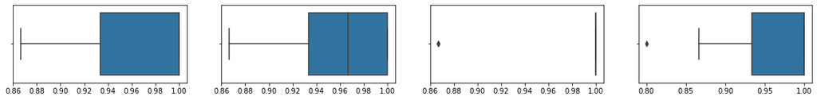

```python
# Supress plot warnings
%%capture --no-display
fig, axes = plt.subplots(1, 4, figsize=(20, 2))

## Boxplot chart plotting
boxplot(KNNaccuracy, ax=axes[0])
boxplot(DTaccuracy, ax=axes[1])
boxplot(MLPaccuracy, ax=axes[2])
boxplot(NBaccuracy, ax=axes[3])
```

```python
# Calculate absolute difference without
print(f"{abs_dif(MLPaccuracy.mean(),MLPaccuracy.std(),KNNaccuracy.mean(),KNNaccuracy.std()):.4f}")
```

```
0.1355
```

##### **Conclusion**

Analisyng this dataset we can say that using any of the tested models we have a good accuracy for defining the correct class (species) of the flower.

### **Leaf**

This dataset contains information about leafs. Our objective will be to classify the species of the leaf.  
This data set still an basic one, still does not have hard pre-processing steps.

#### **Data Frame**

```python
# Header defined to the dataset as specified in UCI site
leaf_header = [
  "Class (Species)",
  "Specimen Number",
  "Eccentricity",
  "Aspect Ratio",
  "Elongation",
  "Solidity",
  "Stochastic Convexity",
  "Isoperimetric Factor",
  "Maximal Indentation Depth",
  "Lobedness",
  "Average Intensity",
  "Average Contrast",
  "Smoothness",
  "Third moment",
  "Uniformity",
  "Entropy"
]

df_leaf = pd.read_csv("leaf.csv", header=None, names=leaf_header)
```

```python
# Basic information about the data set
df_leaf.info()
```

```
<class 'pandas.core.frame.DataFrame'>
RangeIndex: 340 entries, 0 to 339
Data columns (total 16 columns):
 #   Column                     Non-Null Count  Dtype
---  ------                     --------------  -----
 0   Class (Species)            340 non-null    int64
 1   Specimen Number            340 non-null    int64
 2   Eccentricity               340 non-null    float64
 3   Aspect Ratio               340 non-null    float64
 4   Elongation                 340 non-null    float64
 5   Solidity                   340 non-null    float64
 6   Stochastic Convexity       340 non-null    float64
 7   Isoperimetric Factor       340 non-null    float64
 8   Maximal Indentation Depth  340 non-null    float64
 9   Lobedness                  340 non-null    float64
 10  Average Intensity          340 non-null    float64
 11  Average Contrast           340 non-null    float64
 12  Smoothness                 340 non-null    float64
 13  Third moment               340 non-null    float64
 14  Uniformity                 340 non-null    float64
 15  Entropy                    340 non-null    float64
dtypes: float64(14), int64(2)
memory usage: 42.6 KB
```

A portion of the dataframe.

```python
df_leaf.head()
```

|  | Class (Species) | Specimen Number | Eccentricity | Aspect Ratio | Elongation | Solidity | Stochastic Convexity | Isoperimetric Factor | Maximal Indentation Depth | Lobedness | Average Intensity | Average Contrast | Smoothness | Third moment | Uniformity | Entropy |
| --- | --- | --- | --- | --- | --- | --- | --- | --- | --- | --- | --- | --- | --- | --- | --- | --- |
| 0 | 1 | 1 | 0.72694 | 1.4742 | 0.32396 | 0.98535 | 1.00000 | 0.83592 | 0.004657 | 0.003947 | 0.047790 | 0.127950 | 0.016108 | 0.005232 | 0.000275 | 1.17560 |
| 1 | 1 | 2 | 0.74173 | 1.5257 | 0.36116 | 0.98152 | 0.99825 | 0.79867 | 0.005242 | 0.005002 | 0.024160 | 0.090476 | 0.008119 | 0.002708 | 0.000075 | 0.69659 |
| 2 | 1 | 3 | 0.76722 | 1.5725 | 0.38998 | 0.97755 | 1.00000 | 0.80812 | 0.007457 | 0.010121 | 0.011897 | 0.057445 | 0.003289 | 0.000921 | 0.000038 | 0.44348 |
| 3 | 1 | 4 | 0.73797 | 1.4597 | 0.35376 | 0.97566 | 1.00000 | 0.81697 | 0.006877 | 0.008607 | 0.015950 | 0.065491 | 0.004271 | 0.001154 | 0.000066 | 0.58785 |
| 4 | 1 | 5 | 0.82301 | 1.7707 | 0.44462 | 0.97698 | 1.00000 | 0.75493 | 0.007428 | 0.010042 | 0.007938 | 0.045339 | 0.002051 | 0.000560 | 0.000024 | 0.34214 |